FJ

# Feidhelm Joyce

Business & Data Analyst  
Boston, MA

linkedin.com/in/feidhelmjoyce  
github.com/FeidhelmJ

MARKETING ANALYTICS

## Time Series Data & Modeling

← Back to Marketing Analytics

**Part I: Working with Time Series Data**

A.

Pick any publicly-traded company that trades on the Nasdaq or the NYSE.

a. What company did you select, and what is its ticker symbol? Why did you pick this company?

- Eli Lilly - LLY
- Randomly scrolling through companies traded on the Nasdaq and their name popped up, I have a few friends back in Ireland who do or have worked for Lilly before as chemical engineers.

B.

Go to the Nasdaq homepage: www.nasdaq.com. Enter your company’s ticker symbol in “Symbol Search” area near the top of your screen. Next, click on “Historical Quotes” and adjust the settings so that it shows one year’s worth of share price data. Then, click on “Download Historical Data” to download this data as a CSV. (Note: this will work regardless of whether your company trades on the NYSE or Nasdaq – that won’t matter).

C.

Bring the dataset into your environment. For this step, bring the dataset into your environment using read_csv() from pandas -- but now, add some extra parameters to that function: index_col= ‘Date’ and parse_dates=True.

a. Use the head() function to explore the variables, and show your results.

b. Rename the ‘Close/Last’ column to ‘Close’.

c. Next, call the info() function on your dataset, and show your results.

```
import numpy as np
import pandas as pd
import matplotlib.pyplot as plt
import seaborn as sns
```

```
lilly = pd.read_csv('Lilly.csv', index_col = 'Date', parse_dates= True)
```

```
lilly.head()
```

| Date | Close/Last | Volume | Open | High | Low |
| --- | --- | --- | --- | --- | --- |
| 2025-11-18 | $1030.05 | 3430529 | $1014.01 | $1040.7245 | $1014.01 |
| 2025-11-17 | $1021.70 | 4719957 | $1003.72 | $1032.141 | $998.3015 |
| 2025-11-14 | $1025.28 | 3862267 | $1009.00 | $1033.6185 | $1007.785 |
| 2025-11-13 | $1022.87 | 4153595 | $1010.085 | $1032.95 | $1010.085 |
| 2025-11-12 | $1017.78 | 5185236 | $993.12 | $1022.42 | $990.10 |

```
lilly.rename(columns = {'Close/Last': 'Close'}, inplace = True)
```

```
lilly.info()
```

```
<class 'pandas.core.frame.DataFrame'>
DatetimeIndex: 250 entries, 2025-11-18 to 2024-11-19
Data columns (total 5 columns):
 #   Column  Non-Null Count  Dtype
---  ------  --------------  -----
 0   Close   250 non-null    object
 1   Volume  250 non-null    int64
 2   Open    250 non-null    object
 3   High    250 non-null    object
 4   Low     250 non-null    object
dtypes: int64(1), object(4)
memory usage: 11.7+ KB
```

D.

Is this dataframe indexed by time values? How do you know this?

E.

Let’s visualize the entire time series.

a. First, just call .plot() on your dataframe object.

i. Describe what you see here. Why is this a challenging graph to interpret? What would make it easier to understand?

- We can see a simple plot of the volume of Lilly shares being traded over the past 12 months. The x-axis shows us date stamps in 2 month blocks. It's difficult to interpret due to the lack of data surrounding the plot including scale and y-axis labels.

```
lilly.plot()
```

```
<Axes: xlabel='Date'>
```

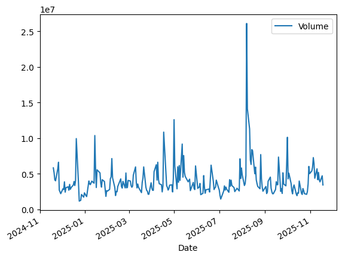

b. Now, re-run the .plot() function, but this time, call that function on the ‘Close’ variable only.

i. Now, in a couple of sentences, describe what you see. Why is this graph more easily interpretable than the one you plotted in the previous step?

- The plot shows Lilly’s closing stock price fluctuating over the year, with several ups and downs followed by a sharp rise toward the end. This graph is easier to interpret because the axes, labels, and visual scale are cleaner and more focused, making the overall trend and major movements in the stock price much clearer than the first raw plot.

```
lilly[['Close','Open','High','Low']] = (lilly[['Close','Open','High','Low']].replace('[\$,]', '', regex=True).astype(float))
```

```
<>:1: SyntaxWarning: invalid escape sequence '\$'
<>:1: SyntaxWarning: invalid escape sequence '\$'
/tmp/ipython-input-2356293187.py:1: SyntaxWarning: invalid escape sequence '\$'
  lilly[['Close','Open','High','Low']] = (lilly[['Close','Open','High','Low']].replace('[\$,]', '', regex=True).astype(float))
```

```
lilly_close_plot = sns.lineplot(data = lilly, x = 'Date', y = 'Close')
lilly_close_plot.set_title('Lilly Stock Closing Price')
lilly_close_plot.set_xlabel('Date')
lilly_close_plot.set_ylabel('Closing Price');
```

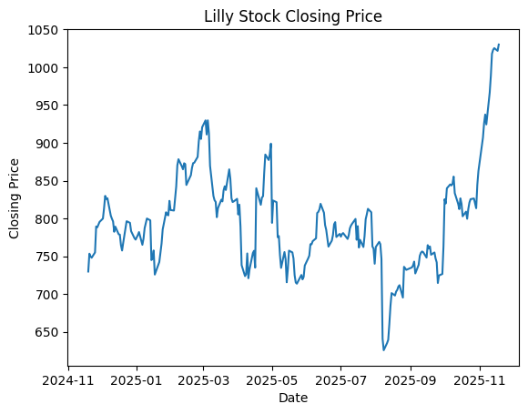

c. Re-plot the ‘Close’ variable, and add a horizontal line representing the average closing price for the year.

i. What does this line help you see more clearly?

- The line clearly helps us visualize the average closing price of Lilly stock for the previous year. Depicting how severe a drop in price the stock took around August, and similarily, highlighting how well the stock is perfoming currently.

```
avg_close = lilly['Close'].mean()
```

```
plt.plot(lilly.index, lilly['Close'], label='Close Price')
plt.title('Lilly Stock Closing Price with yearly average')
plt.xlabel('Date')
plt.ylabel('Closing Price')
plt.axhline(avg_close, color='red', linestyle='--', linewidth=2, label=f'Average Close ({avg_close:.2f})');
```

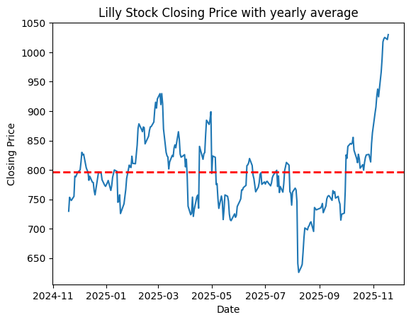

d. Use the .diff() method to calculate the daily change in the ‘Close’ price, and store the result in a new column called 'daily_change'.

i. Plot the 'daily_change' variable.

ii. What does this show that the original closing price plot did not?

- The daily change variable shows us the extreme drops or rises in the stock price that the closing price plot might now catch as it shows more gradual increase or decrease. A perfect example is some of the fluctuations around May of this year, there was a drop of over 100 dollar which is extremely worrying for investors, thanffully for their sake, the stock bounced back quite soon afterwards.

iii. Do you notice any periods of unusually high or low movement?

- As mentioned, that period around May of this year the stock plummeted and rebounded quite well. Upon further investigation, Eli Lilly reduced its earnings per share (EPS) forecast for 2025, despite maintaining its revenue guidance. The adjusted outlook was largely due to a large charge from a recent acquisition.

```
lilly['daily_change'] = lilly['Close'].diff()
```

```
plt.plot(lilly.index, lilly['daily_change'], label='Daily Change')
plt.title('Lilly Stock Daily Change')
plt.xlabel('Date')
plt.ylabel('Daily Change');
```

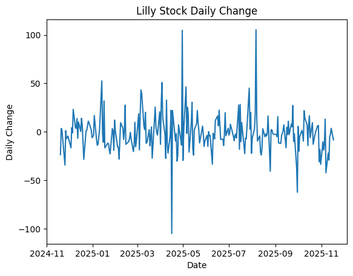

e. Plotting a subset of your data

i. Using a slice operation, plot the daily ‘Close’ variable from your dataset for any one-month period of your choice.

ii. Now, show the plot you drew with the previous step, but with a new figsize, line color, and style.

```
lilly_sorted = lilly.sort_index()
```

```
june_2025 = lilly_sorted.loc['2025-06-01':'2025-06-30']
```

```
plt.figure(figsize=(10, 6))
plt.plot(june_2025.index, june_2025['Close'], color='green', linestyle='--', linewidth=2)
plt.title('Lilly Stock Closing Price in June 2025')
plt.xlabel('Date')
plt.xticks(rotation=45)
plt.ylabel('Closing Price $')
plt.show();
```

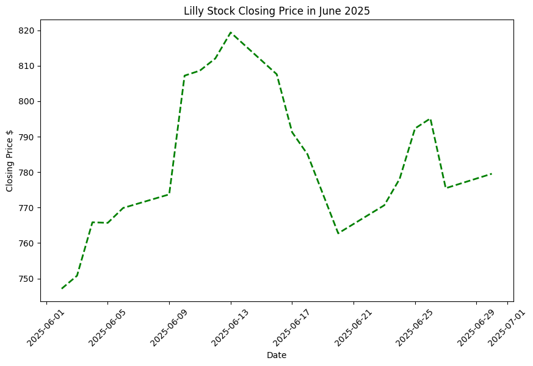

F.

Rolling windows

a. Generate a 20-period moving average for your ‘Close’ variable, and create a plot that overlays this 20-period average atop the actual daily closing prices.

b. Next, generate a 75-period moving average for your ‘Close’ variable, and create a plot that overlays this 75-period average atop the actual daily closing prices.

c. How are your two moving average plots different from one another? What are some pros and cons of shorter and longer moving average windows?

- The 75-period moving average line gives us a smoother, less volatile outlook on the stock price. This would be a preffered MA for longer term investments as isn't affected as harshly by major rises or drops, as we can see from the most recent rise happening currently. This does however mean that this MA method is slower to react to major changes in stock price.
- The 20-period moving average line is a lot more responsive to sharp changes in stock prices. This method however is extremely volatile and can create false signals sometimes when reacting to temporary price movements.

```
lilly_sorted['moving_average'] = lilly_sorted['Close'].rolling(window=20).mean()
```

```
plt.figure(figsize=(10,6))
plt.plot(lilly_sorted['Close'], label='Daily Close', linewidth=1.5)
plt.plot(lilly_sorted['moving_average'], label='20-Day MA', linewidth=2, linestyle='--')
plt.title('Lilly Daily Close Price with 20-Day Moving Average')
plt.xlabel('Date')
plt.ylabel('Price')
plt.legend()
plt.xticks(rotation=45)
plt.show();
```

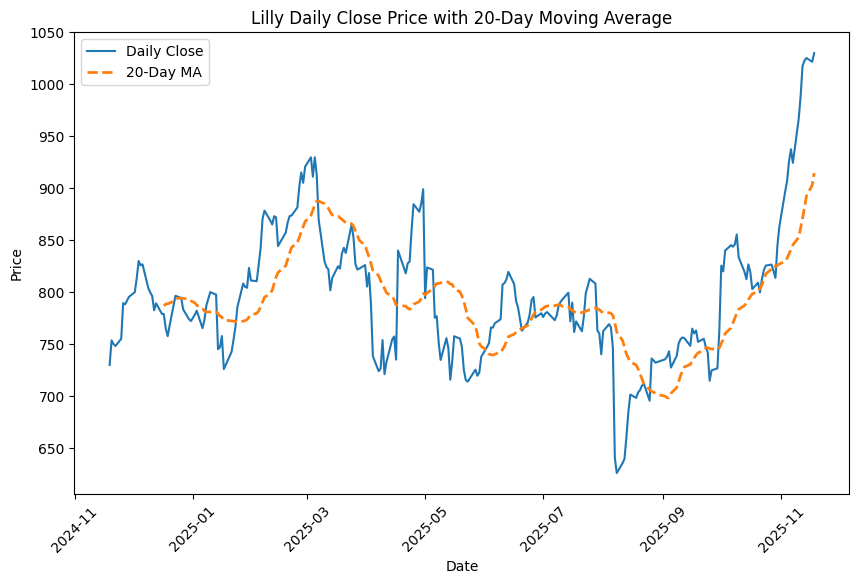

```
lilly_sorted['MA75'] = lilly_sorted['Close'].rolling(75).mean()
```

```
plt.figure(figsize=(10,6))
plt.plot( lilly_sorted['Close'], label='Daily Close', linewidth=1.5)
plt.plot(lilly_sorted['MA75'], label='75-Day MA', linewidth=2, linestyle='--')
plt.title('Lilly Daily Close Price with 75-Day Moving Average')
plt.xlabel('Date')
plt.ylabel('Price')
plt.legend()
plt.xticks(rotation=45)
plt.show();
```

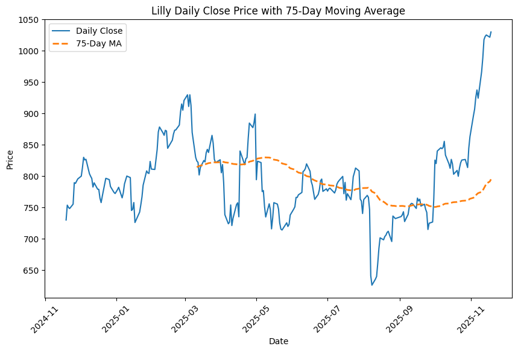

G.

Plot a rolling standard deviation for your time series data. You should be showing the rolling standard deviation for the ‘Close’ variable for this purpose. You can pick the size of the window for the rolling standard deviation.

a. What does your rolling standard deviation plot show you about your time series?

- Looking at the 75-period rolling standard deviation, it shows us the periods in which the stock price fluctuated from the average such as May/June & in November. In contrast, flatter sections of the line such as late summer indicate relatively stable pricing with less day-to-day variation.

```
lilly_sorted['rolling_std_75'] = lilly_sorted['Close'].rolling(window=75).std()
```

```
plt.figure(figsize=(12,6))
plt.plot(lilly_sorted['rolling_std_75'],
         label='75-Day Rolling Std Dev',
         color='purple',
         linewidth=2)
plt.title('75-Day Rolling Standard Deviation of Close Price')
plt.xlabel('Date')
plt.ylabel('Standard Deviation')
plt.legend()
plt.xticks(rotation=45)
plt.show();
```

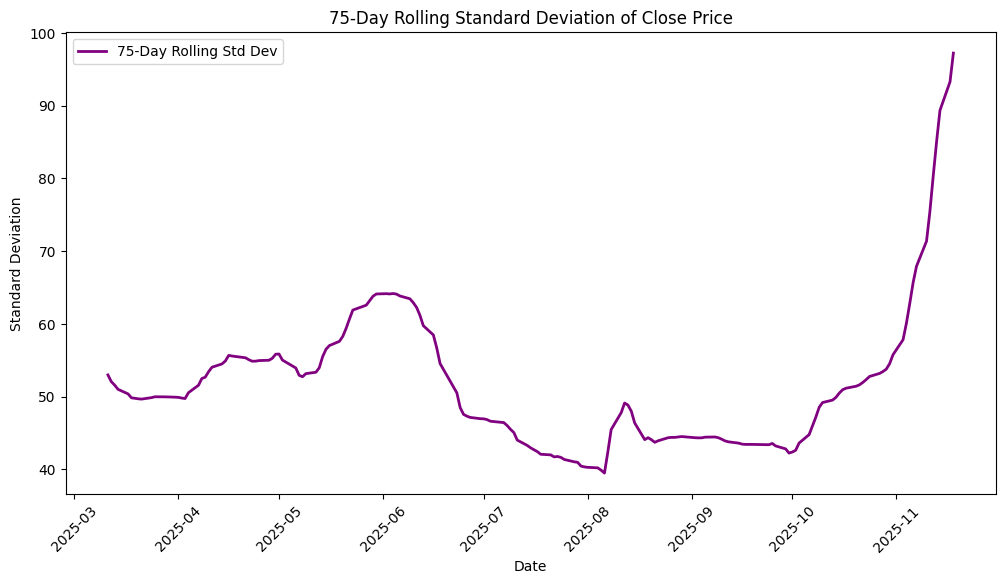

H.

Next, we will try something called resampling.

a. Resample your time series so that its values are based on quarterly time periods’ mean values for ‘Close’, rather than daily periods.

i. Plot this newly-resampled time series, with the dates on the x-axis, and the Close values on the y-axis.

ii. Provide an example that explains why someone might care about resampling a time series. To answer this, you may use ANY other example that you can think of, or discover, from any field that uses time series data (health, weather, etc.) - but do not mention stock market data for this answer, since we’ve already covered it here. You don’t need to perform any outside research or go too deeply into domain knowledge here -- 3-4 thoughtful sentences are all you need.

- A useful example that sprung to mind for me personally was when I look back on my step count. Usually I will check my daily step count to ensure I've at least hit 10-15k steps but then I will resample the data to look back on my weekly and even monthly average. This highlights the days I tend to move the most (Friday's), and those I move the least (Saturday's).

```
quarterly_close = lilly_sorted['Close'].resample('Q').mean()
```

```
/tmp/ipython-input-3160728073.py:1: FutureWarning: 'Q' is deprecated and will be removed in a future version, please use 'QE' instead.
  quarterly_close = lilly_sorted['Close'].resample('Q').mean()
```

```
plt.figure(figsize=(10,5))
plt.plot(quarterly_close, marker='o', linewidth=2, color = 'hotpink')

plt.title('Quarterly Average Close Price')
plt.xlabel('Quarter')
plt.ylabel('Average Close Price')
plt.tight_layout()
plt.show();
```

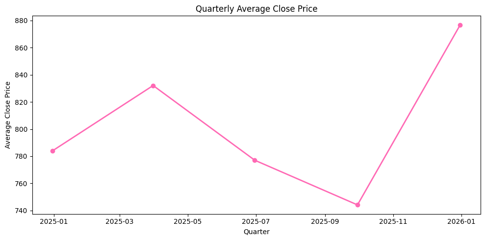

**Part II: Marketing Mix Modeling with an Interaction Term**

1.

After reading the file into your environment, the first question that you will explore here is whether there is any relationship between marketing spending and conversions.

a. To explore this, first create a new variable that shows the total spending. This variable’s value should be the sum of influencer_spend, email_spend, and radio_spend.

```
marketing = pd.read_csv('marketing.csv')
```

```
marketing.head()
```

|  | influencer_spend | email_spend | radio_spend | conversions |
| --- | --- | --- | --- | --- |
| 0 | 28.97 | 62.85 | 28.73 | 45 |
| 1 | 134.30 | 61.11 | 74.28 | 194 |
| 2 | 140.56 | 9.43 | 33.48 | 100 |
| 3 | 72.38 | 21.88 | 76.27 | 73 |
| 4 | 64.35 | 81.06 | 49.26 | 112 |

```
marketing['total_spending'] = marketing['influencer_spend'] + marketing['email_spend'] + marketing['radio_spend']
```

b. Now, find the correlation between this new total spending variable and conversions.

i. What is the correlation between these variables?

- 0.8832213663220719

ii. What does this correlation suggest about the relationship between total marketing spending and conversions?

- These two variables are highly correlated, indicating that a higher total spend on marketing leads to more conversations.

iii. Why can’t we conclude from this that more ad spending leads to more conversions?

- We cannot conclude that higher ad spending causes more conversions because correlation alone does not establish causation. Total marketing spending is a combined variable made up of multiple components such as influencer, email & radio spend so we don’t know which component is driving the relationship. Additionally, other factors such as seasonality, promotions, targeting changes, or external events may influence both spending and conversions.

```
correlation = marketing['total_spending'].corr(marketing['conversions'])
print(f"Coversation correlation with total spending: {correlation}")
```

```
Coversation correlation with total spending: 0.8832213663220719
```

c. Next, let’s explore the relationship among the influencer ad spending, email ad spending, and radio ad spending variables. Examine the correlations among these three variables.

i. Are any of these correlations so high that we might not be able to use them together in a linear model?

```
correlation_matrix = marketing[['influencer_spend', 'email_spend', 'radio_spend']].corr()
print(correlation_matrix)
```

```
                  influencer_spend  email_spend  radio_spend
influencer_spend          1.000000     0.036761     0.113315
email_spend               0.036761     1.000000     0.083123
radio_spend               0.113315     0.083123     1.000000
```

d. Now, build a model that uses conversions as the outcome variable, with influencer spending, email ad spending, and radio ad spending as the input variables. Use the statsmodels library for this step, and all of the remaining steps here.

i. What is the p-value of the F-Statistic for this model? What does this suggest about the model?

- The p-value of the F-statistic is extremely small for this model suggesting that overall, the model is statistically significant and at least one of the variables is a good predictor of conversations.

ii. What are the p-values for each of the individual predictors used in this model? What does this suggest about these predictors?

- influencer_spend: (<0.05) indicating that it is statistically significant and a strong predictor of conversations.
- email_spend: (<0.05) indicating that it is statistically significant and a strong predictor of conversations.
- radio_spend: (>0.05) indicating that it is not statistically significant and not a strong predictor of conversations.

```
import statsmodels.api as sm

X = marketing[['influencer_spend', 'email_spend', 'radio_spend']]
y = marketing['conversions']

X = sm.add_constant(X)

model = sm.OLS(y, X).fit()
print(model.summary())
```

```
                            OLS Regression Results
==============================================================================
Dep. Variable:            conversions   R-squared:                       0.902
Model:                            OLS   Adj. R-squared:                  0.900
Method:                 Least Squares   F-statistic:                     449.0
Date:                Thu, 20 Nov 2025   Prob (F-statistic):           1.80e-73
Time:                        17:18:26   Log-Likelihood:                -679.66
No. Observations:                 150   AIC:                             1367.
Df Residuals:                     146   BIC:                             1379.
Df Model:                           3
Covariance Type:            nonrobust
====================================================================================
                       coef    std err          t      P>|t|      [0.025      0.975]
------------------------------------------------------------------------------------
const              -72.2859      6.100    -11.850      0.000     -84.342     -60.230
influencer_spend     1.2547      0.044     28.483      0.000       1.168       1.342
email_spend          1.5346      0.071     21.600      0.000       1.394       1.675
radio_spend          0.0667      0.084      0.791      0.430      -0.100       0.233
==============================================================================
Omnibus:                        0.657   Durbin-Watson:                   1.986
Prob(Omnibus):                  0.720   Jarque-Bera (JB):                0.748
Skew:                          -0.000   Prob(JB):                        0.688
Kurtosis:                       2.654   Cond. No.                         362.
==============================================================================

Notes:
[1] Standard Errors assume that the covariance matrix of the errors is correctly specified.
```

e. Lobster Land's marketing team is investigating how different types of advertising spend impact the number of conversions. In particular, they want to understand whether the effect of influencer marketing depends on the level of email marketing spend. They need you to create an interaction plot to visualize the relationship between influencer_spend and conversions, across different levels of email_spend.

i. First, create a new variable called email_spend_group by dividing email_spend into three groups: low, medium, and high (you can use pd.qcut() for this).

ii. Then, plot conversions against influencer_spend, using different colored lines for each email_spend_group.

iii. Use seaborn.lmplot() or something similar to draw trend lines for each group.

iv. What do the different slopes tell you? Is there visual evidence of an interaction between influencer_spend and email_spend? How would the lines appear if there were no interaction?

- The slopes tell us that there is visual evidence of an interaction between influencer_spend and email_spend. Looking at the slope of the trend line for the low email spend group, we can see that there is a minimal positive relationship between the two variables but it is evident that when email spend is low, this tends to lead to less conversions, depsite the influencer spend. On the flip side, when email spending and influencer spending are both high, we can see that this has a much more postive effect on the number of conversions. This tells us that influencer marketing is more effictive when paired with higher levels of email spending.

```
marketing['email_spend_group'] = pd.qcut(marketing['email_spend'], q=3, labels=['low', 'medium', 'high'])
```

```
sns.lmplot(data=marketing, x='influencer_spend',y='conversions',
    hue='email_spend_group',
    height=6,
    aspect=1.4,
    scatter_kws={'alpha': 0.5},
    line_kws={'linewidth': 2}
)
plt.title('Interaction: Influencer Spend × Email Spend Group on Conversions')
plt.xlabel('Influencer Spend')
plt.ylabel('Conversions')
plt.show()
```

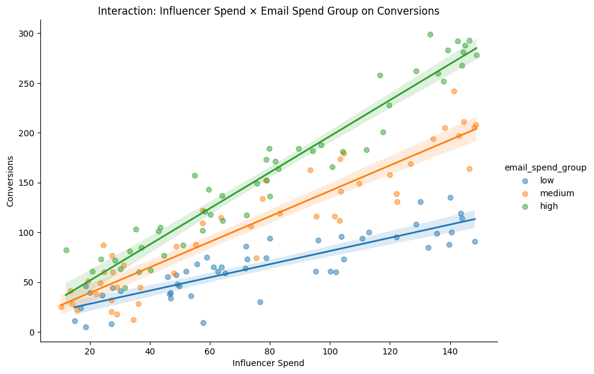

f. Build yet another model -- this time, you will again use conversions as the outcome variable. Your inputs will be influencer ad spending, email ad spending, and an interaction variable for influencer ad spending & email ad spending.

i. What do you notice about the p-values for each of these predictors?

ii. How does the r-squared of this model compare to the r-squared of a model built to predict conversions, but with only influencer spending and email ad spending, but without the interaction term? What does this difference suggest about the inclusion of the interaction? (you will need to generate another model to answer this, but it won’t take long)

- The model including the interaction term has a higher R squared, 0.954 vs. 0.902, indicating that it explains more of the variation in conversions. This improvement suggests that the interaction between influencer spending and email spending is meaningful.

iii. Demonstrate what your model would predict for a marketer using 100 units of influencer ad spending and 50 units of email ad spending. What conversions outcome should this marketer expect to see?

- Roughly 130 conversions.

iv. In a few sentences, how do you interpret the interaction effect between influencer ad spending and email ad spending? What is this effect showing us? (no statistical jargon is required here, but this should make sense to someone who knows about marketing, but not about how to interpret a linear model)

- As mentioned above, the interaction effect shows that influencer spending works better when it’s supported by higher levels of email marketing. When email spending is low, increasing influencer spending leads to only modest gains in conversions. But when email spending is high, the same increase in influencer spending produces a much larger boost in conversions

```
marketing['influencer_email_interaction'] = (marketing['influencer_spend'] * marketing['email_spend'])
```

```
X_2 = marketing[['influencer_spend','email_spend', 'influencer_email_interaction']]
y_2 = marketing['conversions']

X_2 = sm.add_constant(X_2)
interaction_model_2 = sm.OLS(y_2, X_2).fit()
print(interaction_model_2.summary())
```

```
                            OLS Regression Results
==============================================================================
Dep. Variable:            conversions   R-squared:                       0.954
Model:                            OLS   Adj. R-squared:                  0.953
Method:                 Least Squares   F-statistic:                     1011.
Date:                Thu, 20 Nov 2025   Prob (F-statistic):           2.03e-97
Time:                        18:58:42   Log-Likelihood:                -622.98
No. Observations:                 150   AIC:                             1254.
Df Residuals:                     146   BIC:                             1266.
Df Model:                           3
Covariance Type:            nonrobust
================================================================================================
                                   coef    std err          t      P>|t|      [0.025      0.975]
------------------------------------------------------------------------------------------------
const                           -1.4199      6.480     -0.219      0.827     -14.226      11.386
influencer_spend                 0.4262      0.071      5.985      0.000       0.285       0.567
email_spend                      0.3122      0.107      2.922      0.004       0.101       0.523
influencer_email_interaction     0.0147      0.001     12.892      0.000       0.012       0.017
==============================================================================
Omnibus:                        0.195   Durbin-Watson:                   2.134
Prob(Omnibus):                  0.907   Jarque-Bera (JB):                0.301
Skew:                           0.079   Prob(JB):                        0.860
Kurtosis:                       2.847   Cond. No.                     2.81e+04
==============================================================================

Notes:
[1] Standard Errors assume that the covariance matrix of the errors is correctly specified.
[2] The condition number is large, 2.81e+04. This might indicate that there are
strong multicollinearity or other numerical problems.
```

```
X_3 = marketing[['influencer_spend','email_spend']]
y_3 = marketing['conversions']

X_3 = sm.add_constant(X_3)
interaction_model_3 = sm.OLS(y_3, X_3).fit()
print(interaction_model_3.summary())
```

```
                            OLS Regression Results
==============================================================================
Dep. Variable:            conversions   R-squared:                       0.902
Model:                            OLS   Adj. R-squared:                  0.900
Method:                 Least Squares   F-statistic:                     674.9
Date:                Thu, 20 Nov 2025   Prob (F-statistic):           8.37e-75
Time:                        19:18:44   Log-Likelihood:                -679.98
No. Observations:                 150   AIC:                             1366.
Df Residuals:                     147   BIC:                             1375.
Df Model:                           2
Covariance Type:            nonrobust
====================================================================================
                       coef    std err          t      P>|t|      [0.025      0.975]
------------------------------------------------------------------------------------
const              -70.0311      5.387    -13.001      0.000     -80.677     -59.386
influencer_spend     1.2586      0.044     28.784      0.000       1.172       1.345
email_spend          1.5391      0.071     21.759      0.000       1.399       1.679
==============================================================================
Omnibus:                        0.652   Durbin-Watson:                   2.021
Prob(Omnibus):                  0.722   Jarque-Bera (JB):                0.745
Skew:                           0.008   Prob(JB):                        0.689
Kurtosis:                       2.655   Cond. No.                         297.
==============================================================================

Notes:
[1] Standard Errors assume that the covariance matrix of the errors is correctly specified.
```

```
new_data = pd.DataFrame({'const': [1.0],'influencer_spend': [100],'email_spend': [50],'influencer_email_interaction': [100 * 50]})
predicted_conversions = interaction_model_2.predict(new_data)
```

```
predicted_conversions
```

|  | 0 |
| --- | --- |
| 0 | 130.442892 |

**dtype:** float64

g. Find an example, or make up an example, of an interaction term in a model (this can be from the world of marketing, or from anywhere else). A very good answer to the lastpart of this question will include some genuine reaction from you -- finding an example of an interaction effect is only a ‘half-credit’ answer here. i. In a 3-5 sentence paragraph describe what you found (or invented). What are the variables that make up this interaction? Is the effect of their interaction on the outcome positive, or negative? How do you feel about the interaction? Does it make sense to you? Or does it surprise you?

- I am going to slightly plagarise the example we talked about in class the other day regarding food and the combination of certain dishes. Two of my favorite post-night out meals when at home in Ireland is pizza, and a curry from a Chinese. The two meals when eaten independently are usually delicious, however one restaurant in my home town has decided to combine the two meals into yes, a chicken curry pizza. For me, the effect of this interaction is extremely positive, it doesn't make complete sense to me but I love it. There are many people however (and I would guess the majority of the world) who love pizza and also love a Chinese curry but wouldn't dream of combining the two and would say that the effect of this interaction is extremely negative, much like the ice cream & ketchup example.

**Part III: Wildcard: Google Trends**

```
from IPython.display import Image, display
```

```
display(Image(filename='Trends.png'))
```

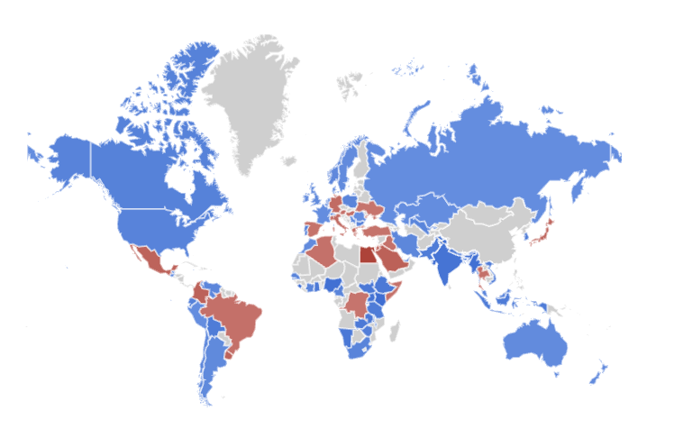

Above is a screenshot of the worldwide interest in my favorite soccer team, Manchester United (blue), and their old rivals, Liverpool. Overall, and looking at the interest over time since 2004, Manchester have always dominated but in recent years Liverpool have also came to the fore. This is likely due to the success of Liverpool under their now ex-manager Jurgen Klopp and the demise of United since the departmure of Sir Alex Ferguson in 2013.

The years where Liverpool have dominated the interest trends are attributed mostly to the years where they have had success on the trophy front, such as their Champions League winning season in 2019. They peaked however in May 2022 which I coudn't put my finger on why as it was Manchester City who won the premier league that year. I then remembered that it was an extremely dramatic final day of the season where Liverpool led in the league standings until the final 30 minutes of the final game.

United dominated the trend searches in the US, Canada and many countries in Africa such as Nigeria & Kenya. I have absolutely no idea why there is such a strong apparent fanbase in certain African nations as United haven't got a strong history in signing African players. Liverpool's strongest region on the other hand in Egypt, which makes complete sense as their talisman for the last 9 years has been Mo Salah, an exceptional player from Egypt nicknamed 'The Egyptian King'.

In terms of related queries, the top rising query for Man Utd was 'man utd vs man city', when I investigated this query the trend was quiet seasonal, on average every 6 months. These spikes can be attributed to when man utd play man city in the league which happens roughly every 6 months.

For Liverpool, the top trending query was ليفربول مباشر , this is translated to 'Liverpool match' from Arabic. Again likely attributed to the volume of Liverpool fans watching from Egypt due to Mo Salah's association with the club.